# Text Mining Practical 2

Regular expressions and word embedding

Javier Garcia Bernardo

Welcome to the second practical on text mining! The aim of this practical is to introduce you how to write the regular expressions and apply a word embedding method to represent the text data.

In this practical, we will perform the followings:

- Visualize the most frequent words in a data set by a word cloud and a bar plot.
- Use regular expressions to retrieve information from text .
- Create word embeddings.
- (optional) Use pre-trained word embeddings.

# Preparation

In this practical, we make use of the following packages:

```r
library(magrittr)  # for pipes
library(tidyverse) # for tidy data and pipes
library(ggplot2)   # for visualization
library(wordcloud) # to create pretty word clouds
library(stringr)   # for regular expressions
library(text2vec)  # for word embedding
library(tidytext)  # for text mining
```

# Text data

We are going to use two data sets in this practical.

- A data set with reviews of computers.  
  It is a data set which is annotated for the purpose of aspect-based sentiment analysis. Aspect-based sentiment analysis is a text analysis technique that categorizes data by specific aspects and identifies the sentiment attributed to each one. This data set is provided in the `computer.txt` file, already located in the data folder of the practical. You can also find it from [here](https://www.cs.uic.edu/~liub/FBS/sentiment-analysis.html).
- A data set with all Harry Potter books.  
  This data set contains the full texts of the first seven Harry Potter books (see below the list). Each text is in a character vector with each element representing a single chapter. It is provided from the [harrypotter package](https://github.com/bradleyboehmke/harrypotter) written by [Bradley Boehmke](https://github.com/bradleyboehmke).
  - philosophers_stone: Harry Potter and the Philosophers Stone, published in 1997
  - chamber_of_secrets: Harry Potter and the Chamber of Secrets, published in 1998
  - prisoner_of_azkaban: Harry Potter and the Prisoner of Azkaban, published in 1999
  - goblet_of_fire: Harry Potter and the Goblet of Fire, published in 2000
  - order_of_the_phoenix: Harry Potter and the Order of the Phoenix, published in 2003
  - half_blood_prince: Harry Potter and the Half-Blood Prince, published in 2005
  - deathly_hallows: Harry Potter and the Deathly Hallows, published in 2007

# Visualization

### 1. Use `readLines` function to read data from the `computer.txt` file. Then, use `data.frame` function to convert it to a dataframe and assign it to an object called `computer_531`.

**Hint**: `data.frame(your var name = readLines("your path to the data file"))`

```r
computer_531 <- data.frame(review = readLines("data/Computer.txt"))
```

### 2. Use `View` function to see the data so that you can get an idea of what they look like.

```r
# View(computer_531)
```

### 3. `wordcloud` is a function from the `wordcloud` package, which plots cool word clouds based on word frequencies in a given data set. Use this function to plot the top 50 frequent words with minimum frequency of 5 using your data set. wordcloud will directly tokenize your documents.

**Hint**: Check the help file of `wordcloud` function (e.g., `?wordcloud`) to see how to specify the arguments.

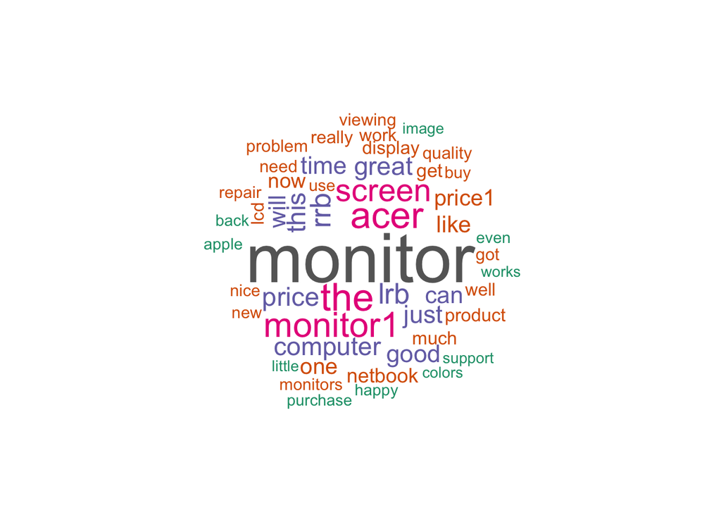

```r
wordcloud(computer_531$review, min.freq = 5,
            max.words = 50, random.order = FALSE,
            colors = brewer.pal(8, "Dark2"))
```

### 4-1. Use `unnest_tokens` function from `tidytext` package to break the text into individual tokens (a process called [tokenization](https://en.wikipedia.org/wiki/Lexical_analysis#Tokenization)) and use `head` function to see its first several rows.

**Hint**: `unnest_tokens(data, output column name, input column name)`

```r
# tokenize texts
comp_words <- computer_531 %>%
  unnest_tokens(word, review)

# check the resulting tokens
head(comp_words)
```

| word |
| --- |
| i |
| purchased |
| this |
| monitor |
| because |
| of |

### 4-2. Use functions from `dplyr` package (e.g., `count`, `arrange`) to select the most frequent 30 tokens and plot a bar chat using `ggplot`.

**Hint**: One of many different ways to achieve this is as follows.  
Step 1. Use `count` function to count the frequency of each word.  
Step 2. Use `arrange` function to sort the counts in descending order (i.e., `arrange(desc(..)))`).  
Step 3. Use `head` function to select the top 30.  
Step 4. use `ggplot` along with `geom_col` function to make a bar plot.

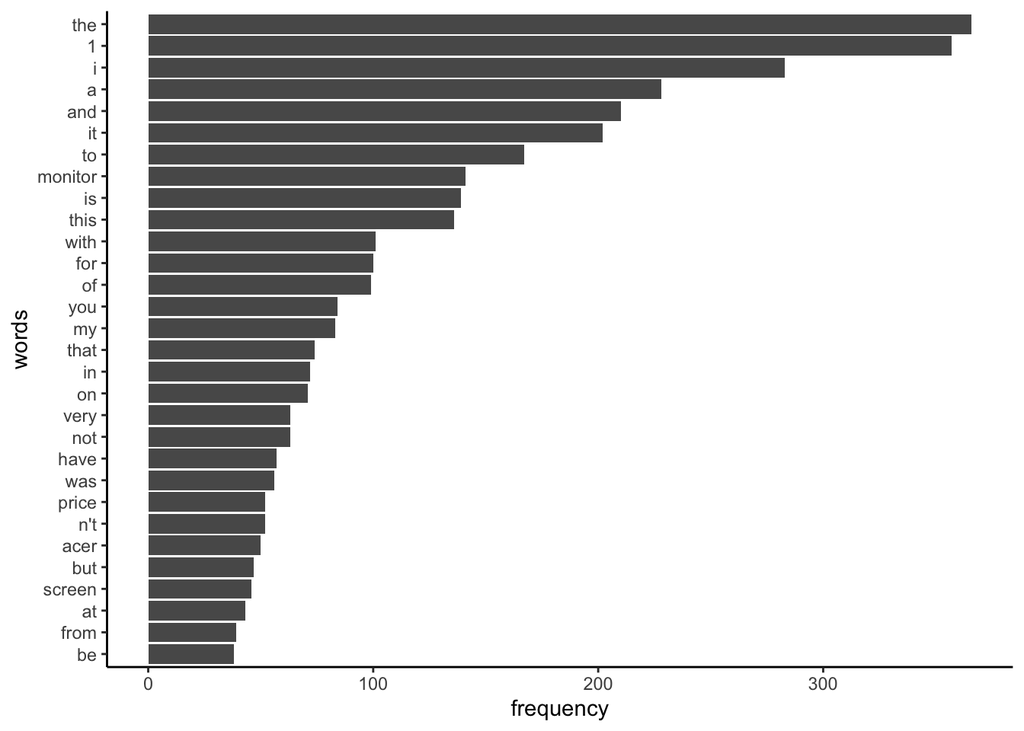

```r
comp_words %>%
  # count the frequency of each word
  count(word) %>%
  # arrange the words by its frequency in descending order
  arrange(desc(n)) %>%
  # select the top 30 most frequent words
  head(30) %>%
  # make a bar plot (reorder words by their frequencies)
  ggplot(aes(x = n, y = reorder(word, n))) + geom_col() +
  labs(x = "frequency", y="words") + theme_classic()
```

Here you see that many of the top words are *stop words*. In the next part of the practical, we will learn how to proceed with pre-processing and remove the stop words!

# Regular expressions

### 5. Use regular expressions (regex) to find the reviews in `computer_531`, which contain words *“Monitor” or “monitor”*, *“memory” or “Memory”*, and *“Delivery” or “delivery”*. See how many reviews contain each pair of words.

**Hint**: One of many different ways to achieve this is as follows.  
Step 1. Use `str_detect` function from `stringr` package to find the presence of patterns of your interest. See the lecture slide if you are unsure how to specify the *regex*.  
Step 2. Use `filter` function to only retain the ones that contain the patterns. You can write in one line such as `filter(str_detect(input vector, regex))`.  
Step 3. Count the number of reviews that contain each pattern.

```r
# reviews containing "Monitor" or "monitor"
reviews_mon <- computer_531 %>%
  filter(str_detect(review,"[Mm]onitor"))

# reviews containing "memory" or "Memory"
reviews_mem <- computer_531 %>%
  filter(str_detect(review,"[Mm]emory"))

# reviews containing "Delivery" or "delivery"
reviews_del <- computer_531 %>%
  filter(str_detect(review,"[Dd]elivery"))

# compare the occurrence of each pair of words
kwords    <- c("Monitor", "Memory", "Delivery")
nr_kwords <- c(nrow(reviews_mon), nrow(reviews_mem), nrow(reviews_del))

tibble(kwords, nr_kwords)
```

| kwords | nr_kwords |
| --- | --- |
| Monitor | 105 |
| Memory | 5 |
| Delivery | 3 |

### 6. Compare `str_detect`, `str_extract`, `str_subset` and `str_match` functios from `stringr` package to check if there are any fully capitalized words in the reviews from the `computer_531` data set.

```r
## Detect
head(str_detect(computer_531$review, '\\b[A-Z]+\\b'))
```

```
[1]  TRUE  TRUE FALSE FALSE  TRUE  TRUE
```

```r
## Extract
head(str_extract(computer_531$review, '\\b[A-Z]+\\b'))
```

```
[1] "I" "I" NA  NA  "I" "A"
```

```r
## Subset
head(str_subset(computer_531$review, '\\b[A-Z]+\\b'))
```

```
[1] "## I purchased this monitor because of budgetary concerns ."
[2] "inexpensive[+1][a] ## This item was the most inexpensive 17 inch monitor available to me at the time I made the purchase ."
[3] "monitor[-1], picture quality[-1] ## I 've viewed numerous different monitor models since I 'm a college student and this particular monitor had as poor of picture quality as any I 've seen ."
[4] "screen[-1] ## A week out of the box and I began to see slight contractions of the screen from time to time , growing more frequent each day ."
[5] "monitor[-1] ## I could tell this was a `` cheap '' monitor as soon as I set it up ."
[6] "## I sent it back and now will search for a better quality monitor ."
```

```r
## Match (Useful with captures groups)
head(str_match(computer_531$review, '\\b([A-Z])+\\b'))
```

```
     [,1] [,2]
[1,] "I"  "I"
[2,] "I"  "I"
[3,] NA   NA
[4,] NA   NA
[5,] "I"  "I"
[6,] "A"  "A"
```

### 7. You can also use `str_extract_all` and `str_match_all` to extract all matches. Use either of these functions to see all of the fully capitalized words in the first 10 reviews.

```r
# use str_extract_all
sapply(str_extract_all(computer_531$review[1:10], '\\b[A-Z]+\\b'), paste, collapse =" ")
```

```
 [1] "I"     "I"     ""      ""      "I I I" "A I"   ""      "I I"   "I"
[10] "I"
```

```r
# use str_match_all
sapply(str_match_all(computer_531$review[1:10], '\\b[A-Z]+\\b'), paste, collapse = " ")
```

```
 [1] "I"     "I"     ""      ""      "I I I" "A I"   ""      "I I"   "I"
[10] "I"
```

The output from `str_extract_all`/`str_match_all` is a list, which can be pasted together by using `sapply`.

### 8. In order to separate aspects and sentiments in the reviews from the `computer_531` data, let’s first use a regular expression to extract the characters at the beginning of each line until `##`. Do this for only the first 20 reviews.

**Hint**: Use `str_extract` function such that `str_extract(first 20 reviews, regex)`.

```r
str_extract(computer_531[1:20,], "[^#]*")
```

```
 [1] ""                                  "inexpensive[+1][a] "
 [3] "monitor[-1] "                      "screen[-1], picture quality[-1] "
 [5] "monitor[-1], picture quality[-1] " "screen[-1] "
 [7] "Display[-1] "                      "monitor[-1] "
 [9] ""                                  ""
[11] ""                                  ""
[13] ""                                  "monitor[-1], colors[-1] "
[15] ""                                  "size[+1] "
[17] "computer[+1], quality[+1] "        ""
[19] "keyboard[+1], color[+1] "          "speed[+1], memory[+1] "
```

### 9. Add a new column to the `computer_531` data frame with the name `cleaned_review`, which contains only the review text. And add another column with the name `aspect_sentiment`, which contains the asepcts and sentiment words (i.e., the ones at the end of each review text).

**Hint**: Use `mutate` and `str_extract` function (e.g., `mutate(cleaned_review = str_extract(...), aspect_sentiment = str_extract(...))`).

```r
computer_531 <- computer_531 %>%
  mutate(cleaned_review = str_extract(review,"##.*"),
         aspect_sentiment = str_extract(review,".*##"))

# check the newly added columns
head(computer_531[-1])
```

| cleaned_review | aspect_sentiment |
| --- | --- |
| ## I purchased this monitor because of budgetary concerns . | ## |
| ## This item was the most inexpensive 17 inch monitor available to me at the time I made the purchase . | inexpensive[+1][a] ## |
| ## My overall experience with this monitor was very poor . | monitor[-1] ## |
| ## When the screen was n’t contracting or glitching the overall picture quality was poor to fair . | screen[-1], picture quality[-1] ## |
| ## I ’ve viewed numerous different monitor models since I ’m a college student and this particular monitor had as poor of picture quality as any I ’ve seen . | monitor[-1], picture quality[-1] ## |
| ## A week out of the box and I began to see slight contractions of the screen from time to time , growing more frequent each day . | screen[-1] ## |

### 10. Run the following code below to create a new column `sentiment` with the values `positive`, `negative` and `neutral`. Assign `neutral` in case when there is no aspect in the corresponding column or the sum of scores is equal to zero. Assign negative (positive) when the sum score is lower (higher) than zero.

```r
# define sum_list function which adds the scores
sum_list <- function(list_values) {
 sum(as.numeric(list_values))
}

computer_531 <- computer_531 %>%
  # sentiment_score: extract the scores and sum them using the sum_list function
  mutate(sentiment_score = map_dbl(str_extract_all(aspect_sentiment, "-?\\d+"), sum_list),
                                # assign negative when score < 0
         sentiment = case_when(sentiment_score < 0 ~ "negative",
                               # assign negative when score > 0
                               sentiment_score > 0 ~ "positive",
                               # assign neutral otherwise
                               TRUE ~ "neutral"))

head(computer_531)
```

Table continues below

| review | cleaned_review |
| --- | --- |
| ## I purchased this monitor because of budgetary concerns . | ## I purchased this monitor because of budgetary concerns . |
| inexpensive[+1][a] ## This item was the most inexpensive 17 inch monitor available to me at the time I made the purchase . | ## This item was the most inexpensive 17 inch monitor available to me at the time I made the purchase . |
| monitor[-1] ## My overall experience with this monitor was very poor . | ## My overall experience with this monitor was very poor . |
| screen[-1], picture quality[-1] ## When the screen was n’t contracting or glitching the overall picture quality was poor to fair . | ## When the screen was n’t contracting or glitching the overall picture quality was poor to fair . |
| monitor[-1], picture quality[-1] ## I ’ve viewed numerous different monitor models since I ’m a college student and this particular monitor had as poor of picture quality as any I ’ve seen . | ## I ’ve viewed numerous different monitor models since I ’m a college student and this particular monitor had as poor of picture quality as any I ’ve seen . |
| screen[-1] ## A week out of the box and I began to see slight contractions of the screen from time to time , growing more frequent each day . | ## A week out of the box and I began to see slight contractions of the screen from time to time , growing more frequent each day . |

| aspect_sentiment | sentiment_score | sentiment |
| --- | --- | --- |
| ## | 0 | neutral |
| inexpensive[+1][a] ## | 1 | positive |
| monitor[-1] ## | -1 | negative |
| screen[-1], picture quality[-1] ## | -2 | negative |
| monitor[-1], picture quality[-1] ## | -2 | negative |
| screen[-1] ## | -1 | negative |

We can use this pre-processed data in the practical 3 for the purpose of sentiment classification.

# Word embeddings

In this part of the practical, we will apply word embedding approaches. A key idea in working with text data concerns representing words as numeric quantities. There are a number of ways to go about this as we reviewed in the lecture. One method that we want to explore today is word embedding. Word embedding techniques such as word2vec and GloVe use neural networks approaches to construct word vectors. With these vector representations of words we can see how similar they are to each other, and also perform other tasks such as sentiment classification.

Let’s start the word embedding part with installing the `harrypotter` package using [devtools](https://www.r-project.org/nosvn/pandoc/devtools.html). The `harrypotter` package supplies the first seven novels in the Harry Potter series. You can install and load this package with the following code:

```r
# devtools::install_github("bradleyboehmke/harrypotter")
library(harrypotter) # Not to be confused with the CRAN palettes package
```

### 11. Use the code below to load the first seven novels in the Harry Potter series.

```r
hp_books <- c("philosophers_stone", "chamber_of_secrets",
              "prisoner_of_azkaban", "goblet_of_fire",
              "order_of_the_phoenix", "half_blood_prince",
              "deathly_hallows")

hp_words <- list(
  philosophers_stone,
  chamber_of_secrets,
  prisoner_of_azkaban,
  goblet_of_fire,
  order_of_the_phoenix,
  half_blood_prince,
  deathly_hallows
) %>%
  # name each list element
  set_names(hp_books) %>%
  # convert each book to a data frame and merge into a single data frame
  map_df(as_tibble, .id = "book") %>%
  # convert book to a factor
  mutate(book = factor(book, levels = hp_books)) %>%
  # remove empty chapters
  filter(!is.na(value)) %>%
  # create a chapter id column
  group_by(book) %>%
  mutate(chapter = row_number(book))
```

**Check `hp_words` object using `head` function.**

```r
head(hp_words)
```

| book | value | chapter |
| --- | --- | --- |
| philosophers_stone | THE BOY WHO LIVED Mr. and Mrs. Dursley, of number four, Privet Drive, were proud to say that they were perfectly normal, thank you very much. They were the last people you’d expect to be involved in a… | 1 |
| philosophers_stone | THE VANISHING GLASS Nearly ten years had passed since the Dursleys had woken up to find their nephew on the front step, but Privet Drive had hardly changed at all. The sun rose on the same tidy front … | 2 |
| philosophers_stone | THE LETTERS FROM NO ONE The escape of the Brazilian boa constrictor earned Harry his longest-ever punishment. By the time he was allowed out of his cupboard again, the summer holidays had started and … | 3 |
| philosophers_stone | THE KEEPER OF THE KEYS BOOM. They knocked again. Dudley jerked awake. “Where’s the cannon?” he said stupidly. There was a crash behind them and Uncle Vernon came skidding into the room. He was holding… | 4 |
| philosophers_stone | DIAGON ALLEY Harry woke early the next morning. Although he could tell it was daylight, he kept his eyes shut tight. “It was a dream, he told himself firmly.”I dreamed a giant called Hagrid came to te… | 5 |
| philosophers_stone | THE JOURNEY FROM PLATFORM NINE AND THREE-QUARTERS Harry’s last month with the Dursleys wasn’t fun. True, Dudley was now so scared of Harry he wouldn’t stay in the same room, while Aunt Petunia and Unc… | 6 |

### 12. Convert the `hp_words` object into a dataframe and use the `unnest_tokens` function from the `tidytext` package to tokenize the dataframe.

**Hint**: Use `as.data.frame` function to convert `hp_words` to a dataframe. Then, plug in the resulting dataframe to `unnest_tokens` such as `unnest_tokens(dataframe, output column name, input column name)`.

```r
# tokenize the data frame
hp_words <- as.data.frame(hp_words) %>%
  unnest_tokens(word, value)

head(hp_words)
```

| book | chapter | word |
| --- | --- | --- |
| philosophers_stone | 1 | the |
| philosophers_stone | 1 | boy |
| philosophers_stone | 1 | who |
| philosophers_stone | 1 | lived |
| philosophers_stone | 1 | mr |
| philosophers_stone | 1 | and |

### 13. Remove the stop words from the tokenized data frame.

**Hint**: Use `anti_join` function to filter the `stop_words` from the `tidytext` package. Check the help file if you want further information on either one (e.g., `?anti_join`, `?stop_words`).

```r
hp_words <- hp_words %>%
  # remove stop words
  anti_join(stop_words)

head(hp_words)
```

| book | chapter | word |
| --- | --- | --- |
| philosophers_stone | 1 | boy |
| philosophers_stone | 1 | lived |
| philosophers_stone | 1 | dursley |
| philosophers_stone | 1 | privet |
| philosophers_stone | 1 | drive |
| philosophers_stone | 1 | proud |

### 14. Creates a vocabulary of unique terms using the `create_vocabulary` function from the `text2vec` package and remove the words that they appear less than 5 times.

**Hint**: Follow the steps below.  
Step 1. Create a list of words from `hp_words` (iterator object) using `list` function.  
Step 2. Apply `itoken` function on the word list to create index-tokens.  
Step 3: Apply `create_vocabulary` function on the `itoken` object to collect unique terms.  
Step 4: Apply `prune_vocabulary` on the dataframe of unique terms and specify `term_count_min = 5` to filter the infrequent terms.

```r
# make it a list (iterator)
hp_words_ls <- list(hp_words$word)

# create index-tokens
it <- itoken(hp_words_ls, progressbar = FALSE)

# collects unique terms
hp_vocab <- create_vocabulary(it)

# filters the infrequent terms (number of occurrence is less than 5)
hp_vocab <- prune_vocabulary(hp_vocab, term_count_min = 5)

# show the resulting vocabulary object
DT::datatable(hp_vocab, options = list(dom = 'tp'))
```

|  | term | term_count | doc_count |
| --- | --- | --- | --- |
| 15168 | 10 | 5 | 1 |
| 15169 | aaaah | 5 | 1 |
| 15170 | aargh | 5 | 1 |
| 15171 | abysmal | 5 | 1 |
| 15172 | acts | 5 | 1 |
| 15173 | adjusted | 5 | 1 |
| 15174 | adopted | 5 | 1 |
| 15175 | advertisement | 5 | 1 |
| 15176 | advisable | 5 | 1 |
| 15177 | advising | 5 | 1 |

[output cut: 8618 more lines]

We’ve just created word counts, that’s all the vocabulary object is!

### 15. The next step is to create a [token co-occurrence matrix](https://stackoverflow.com/questions/24073030/what-are-co-occurence-matrixes-and-how-are-they-used-in-nlp)(TCM). First, we need to apply `vocab_vectorizer` function to transform the list of tokens in to vector space. Then, use `create_tcm` function to create a TCM with the window of 5 for context words.

**Hint**: Follow the steps below.  
Step 1: Map the words to indices by `vocab_vectorizer(vocabulary object from Q14)`.  
Step 2: Create a TCM by `create_tcm(it, vectorizer function from Step 1, skip_grams_window = 5)`. `it` is the list of iterators over tokens from `itoken`.

```r
# maps words to indices
vectorizer <- vocab_vectorizer(hp_vocab)

# use window of 5 for context words
hp_tcm <- create_tcm(it, vectorizer, skip_grams_window = 5)
```

Note that such a matrix will be extremely sparse. Most words do not go with other words in the grand scheme of things. So when they do, it usually matters.

### 16. Use the GlobalVectors as given in the code below to fit the word vectors on our data set. Choose the embedding size (rank variable) equal to 50, and the maximum number of co-occurrences equal to 10. Train word vectors in 20 iterations. You can check the full input arguments of the fit_transform function from [here](https://www.rdocumentation.org/packages/text2vec/versions/0.5.1/topics/GlobalVectors).

```r
glove <- GlobalVectors$new(rank = 50, x_max = 10)
hp_wv_main <- glove$fit_transform(hp_tcm, n_iter = 20, convergence_tol = 0.001)
```

```
INFO  [18:20:39.669] epoch 1, loss 0.1180
INFO  [18:20:40.517] epoch 2, loss 0.0783
INFO  [18:20:41.300] epoch 3, loss 0.0679
INFO  [18:20:42.046] epoch 4, loss 0.0618
INFO  [18:20:42.767] epoch 5, loss 0.0575
INFO  [18:20:43.549] epoch 6, loss 0.0543
INFO  [18:20:44.342] epoch 7, loss 0.0519
INFO  [18:20:45.080] epoch 8, loss 0.0499
INFO  [18:20:45.860] epoch 9, loss 0.0482
INFO  [18:20:46.637] epoch 10, loss 0.0468
INFO  [18:20:47.418] epoch 11, loss 0.0456
INFO  [18:20:48.183] epoch 12, loss 0.0446
INFO  [18:20:49.008] epoch 13, loss 0.0437
INFO  [18:20:49.871] epoch 14, loss 0.0429
INFO  [18:20:50.646] epoch 15, loss 0.0422
INFO  [18:20:51.465] epoch 16, loss 0.0416
INFO  [18:20:52.230] epoch 17, loss 0.0411
INFO  [18:20:53.088] epoch 18, loss 0.0405
INFO  [18:20:53.878] epoch 19, loss 0.0401
INFO  [18:20:54.665] epoch 20, loss 0.0396
```

### 17. The GloVe model learns two sets of word vectors: main and context. Essentially they are the same since the model is symmetric. From the experience learning two sets of word vectors leads to higher quality embeddings (read more [here](http://text2vec.org/glove.html)). Best practice is to combine both the main word vectors and the context word vectors into one matrix. Extract the word vectors and save the summation of them for further questions.

**Hint**: Follow the steps below.  
Step 1. Extract context word vectors by `glove$componets`.  
Step 2. Sum two sets of word vectors (e.g., `hv_wv_main + t(hp_wv_context)`).

```r
# extract context word vector
hp_wv_context <- glove$components

# check the dimension for both matrices
dim(hp_wv_main); dim(hp_wv_context)
[1] 8628   50
[1]   50 8628

# Either word-vectors matrices could work, but the developers of the technique
# suggest the sum/mean may work better
hp_word_vectors <- hp_wv_main + t(hp_wv_context) # transpose one matrix to perform matrix addition
```

### 18. Find the most similar 10 words to each of the words: “harry”, “death”, and “love”.

**Hint**: Follow the steps below.  
Step 1. Extract the row of the corresponding word from the word vector matrix (e.g., matrix[“harry”, , drop = FALSE]).  
Step 2. Use `sim2` function with the cosine similarity measure to calculate the pairwise similarities between the chosen row vector (from Step 1) and the rest of words: `sim2(x = whole word vector matrix, y = chosen row vector, method = "cosine", norm = "l2")`.  
Step 3. Sort the resulting column vector of similarities in descending order and present the first 10 values. For example, you can do this by `head(sort(similarity vector, decrasing = TRUE), 10)`.  
Step 4. Repeat *Step 1* - *Step 3* for the other words.

```r
# extract the row of "harry"
harry <- hp_word_vectors["harry", , drop = FALSE]
# calculates pairwise similarities between"harry" and the rest of words
cos_sim_harry <- sim2(x = hp_word_vectors, y = harry, method = "cosine", norm = "l2")
# the top 10 words with the highest similarities
head(sort(cos_sim_harry[,1], decreasing = T), 10)
```

```
    harry       ron  hermione    moment      time    looked      left  happened
1.0000000 0.8820779 0.8640776 0.8326568 0.8169798 0.7745901 0.7555882 0.7440987
  quickly  suddenly
0.7081622 0.7055786
```

```r
# extract the row of "death"
death <- hp_word_vectors["death", , drop = FALSE]
# calculates pairwise similarities between"harry" and the rest of words
cos_sim_death <- sim2(x = hp_word_vectors, y = death, method = "cosine", norm = "l2")
# the top 10 words with the highest similarities
head(sort(cos_sim_death[,1], decreasing = T), 10)
```

```
    death    eaters     eater voldemort   escaped    killed     fight    people
1.0000000 0.9404200 0.8663348 0.6649544 0.5761400 0.5749644 0.5690384 0.5547949
     kill     alive
0.5487107 0.5286173
```

```r
# extract the row of "love"
love <- hp_word_vectors["love", , drop = FALSE]
# calculates pairwise similarities between"harry" and the rest of words
cos_sim_love <- sim2(x = hp_word_vectors, y = love, method = "cosine", norm = "l2")
# top 10 words with the highest similarities
head(sort(cos_sim_love[,1], decreasing = T), 10)
```

```
       love       lucky      potion     suppose ingredients       bring
  1.0000000   0.5754029   0.5644878   0.5639024   0.5442679   0.5232031
    potions       truth     reckons       proof
  0.5195653   0.5142866   0.4839825   0.4825928
```

### 19. Now you can play with word vectors! For example, add the word vector of “harry” with the word vector of “love” and subtract them from the word vector of “death”. What are the top terms in your result?

**Hint**: You can literally add/subtract the word vectors to each other (e.g., harry word vector + love word vector - death word vector). Once you have the resulting vector, calculate similarities as you did previously in Question 18.

```r
# add/subtract word vectors
test <- harry + love - death
# calculates pairwise similarities between"harry" and the rest of words
cos_sim_test <- sim2(x = hp_word_vectors, y = test, method = "cosine", norm = "l2")
# top 10 words with the highest similarities
head(sort(cos_sim_test[,1], decreasing = T), 10)
```

```
 hermione     harry       ron        er      time      yeah     ginny     added
0.6889873 0.6853749 0.6838798 0.5573666 0.5537462 0.5503985 0.5421203 0.5375300
  quickly       bit
0.5307052 0.5195648
```

# OPTIONAL: Wikipedia word embeddings

### 20. Repeat the same analysis as for Harry Potter novel series with texts from Wikipedia. Start with the code below and train the word vectors using the wiki object.

```r
# The data file is provided in the practical folder which you need to unzip it,
# if you do not have it the rest of the code will download it for you
text8_file <- "data/text8/text8"
if (!file.exists(text8_file)) {
  download.file("http://mattmahoney.net/dc/text8.zip", "data/text8.zip")
  unzip("data/text8.zip", files = "text8", exdir = "data/texts_raw/")
}
wiki <- readLines(text8_file, n = 1, warn = FALSE)
```

```r
tokens <- space_tokenizer(wiki)
it <- itoken(tokens, progressbar = FALSE)
vocab <- create_vocabulary(it)
vocab <- prune_vocabulary(vocab, term_count_min = 5L)
vectorizer <- vocab_vectorizer(vocab)

tcm <- create_tcm(it, vectorizer, skip_grams_window = 5L)

glove <- GlobalVectors$new(rank = 50, x_max = 10)

wv_main <- glove$fit_transform(tcm, n_iter = 20, convergence_tol = 0.001)
```

```
INFO  [10:19:31.790] epoch 1, loss 0.1678
INFO  [10:19:46.394] epoch 2, loss 0.1213
INFO  [10:20:00.872] epoch 3, loss 0.1073
INFO  [10:20:15.285] epoch 4, loss 0.0995
INFO  [10:20:29.724] epoch 5, loss 0.0944
INFO  [10:20:44.314] epoch 6, loss 0.0908
INFO  [10:20:58.740] epoch 7, loss 0.0881
INFO  [10:21:13.154] epoch 8, loss 0.0860
INFO  [10:21:27.558] epoch 9, loss 0.0843
INFO  [10:21:42.082] epoch 10, loss 0.0829
INFO  [10:21:56.702] epoch 11, loss 0.0817
INFO  [10:22:11.191] epoch 12, loss 0.0806
INFO  [10:22:25.664] epoch 13, loss 0.0797
INFO  [10:22:40.230] epoch 14, loss 0.0789
INFO  [10:22:54.880] epoch 15, loss 0.0782
INFO  [10:23:09.561] epoch 16, loss 0.0776
INFO  [10:23:24.669] epoch 17, loss 0.0771
INFO  [10:23:39.740] epoch 18, loss 0.0766
INFO  [10:23:54.525] epoch 19, loss 0.0761
INFO  [10:24:09.258] epoch 20, loss 0.0757
```

```r
wv_context <- glove$components
word_vectors <- wv_main + t(wv_context)
```

### 21. Time to play with the trained Wikipedia word vectors! Use the Wikipedia word embeddings and try the two famous examples below.

- Example 1) king - man + woman = queen
- Example 2) Paris - France + Germany = Berlin

```r
berlin <- word_vectors["paris", , drop = FALSE] -
  word_vectors["france", , drop = FALSE] +
  word_vectors["germany", , drop = FALSE]
berlin_cos_sim <- sim2(x = word_vectors, y = berlin, method = "cosine", norm = "l2")
head(sort(berlin_cos_sim[,1], decreasing = TRUE), 5)
```

```
    paris    berlin    vienna   germany    munich
0.7660827 0.7394672 0.7116095 0.6939379 0.6550686
```

```r
queen <- word_vectors["king", , drop = FALSE] -
  word_vectors["man", , drop = FALSE] +
  word_vectors["woman", , drop = FALSE]
queen_cos_sim <- sim2(x = word_vectors, y = queen, method = "cosine", norm = "l2")
head(sort(queen_cos_sim[,1], decreasing = TRUE), 20)
```

```
       king     emperor         son         iii         xiv     william
  0.9009282   0.7134084   0.7089926   0.7025046   0.6865533   0.6768395
  frederick       henry   alexander          iv       louis      prince
  0.6756223   0.6645850   0.6523512   0.6497564   0.6496794   0.6404804
        vii     charles     brother      father       kings          ii
  0.6379013   0.6318206   0.6308704   0.6212580   0.6212299   0.6209884
constantine   succeeded
  0.6187523   0.6175631
```